# Scoring PCSF subnetworks by signed propagation

Can a subnetwork predict the expression it claims to explain? TCGA-THCA

16 August 2026

# What this is

`pcsfomics` builds a subnetwork with a Prize-Collecting Steiner Forest and then faces an awkward question: **is the recovered subnetwork any good?** The PCSF objective value answers “did the solver do its job”, not “does this subnetwork describe biology”. Node count rewards permissiveness. Neither is a scientific criterion.

This report tests a different idea. OmniPath edges carry **direction and sign** (activation / inhibition). That makes a subnetwork a *causal hypothesis*: given seed genes in known states, the wiring predicts the state of everything downstream. Comparing that prediction against observed differential expression gives a goodness score grounded in mechanism.

The cross-modal version is the one that matters here, and it is the project’s founding story stated as a falsifiable prediction:

> Seed with **methylation**. Score against **expression**. A gene’s promoter hypermethylation should silence it, and its regulon should shift accordingly.

Because the two modalities never touch the same gene, the test cannot be satisfied by circularity.

# 1. The model

$$\hat{s} \;=\; \sum_{k=1}^{K}
\lambda^{k}\,\bigl(W_{\text{norm}}^{\mathsf T}\bigr)^{k}\,
s_0$$

$W[i,j]$ is the signed, curation-weighted influence of $i$ on $j$; $s_0$ holds seed states. Columns are normalised so a target’s incoming influence is a weighted **mean** over its regulators — otherwise a gene with fifty regulators dominates by degree alone. Damping ($\lambda<1$, finite $K$) stops feedback loops ringing, which matters because regulatory graphs are dense in cycles.

The signed directed substrate.

| Quantity | Value |
| --- | --- |
| Interactions in OmniPath export | 86,187 |
| Directed | 86,187 (100%) |
| Signed (activation or inhibition) | 70,854 (82%) |
| Usable signed edges after cleaning | 70,389 |
| Nodes in signed graph | 7,093 |

# 2. Validation on planted ground truth

A negative result is uninterpretable unless the machinery provably recovers signal that *is* there. Three checks, all in `test_propagation.R`.

## 2.1 Sign algebra

The smallest possible test: inhibition must flip sign, and double inhibition must restore it.

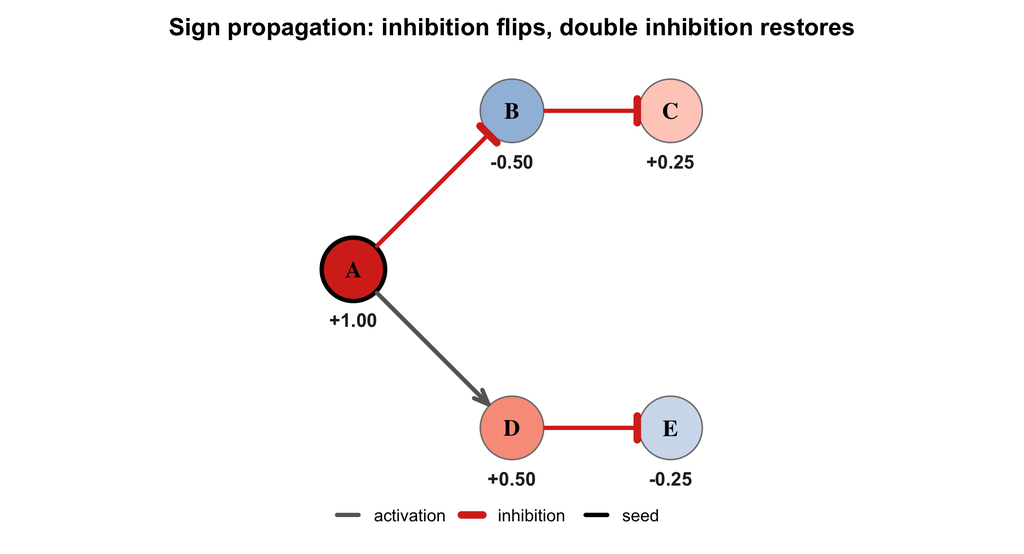

Sign propagation on a hand-built network. Seed A = +1 (black ring). Node fill is the propagated state: red positive, blue negative, with the value printed beneath. Blunt red connectors are inhibition, grey arrows activation.

`A ⊣ B` drives B negative; `B ⊣ C` flips it back positive; `A → D ⊣ E` gives D positive, E negative. Sign algebra is correct.

## 2.2 Planted-signal recovery, and a metric that was lying

Planting a known signal in a random signed graph and adding noise exposed a **flaw in the original scoring metric**. Propagation reaches many genes whose predicted magnitude is essentially zero, and their predicted *sign* is arbitrary. Grading those drags accuracy toward 0.5 regardless of truth.

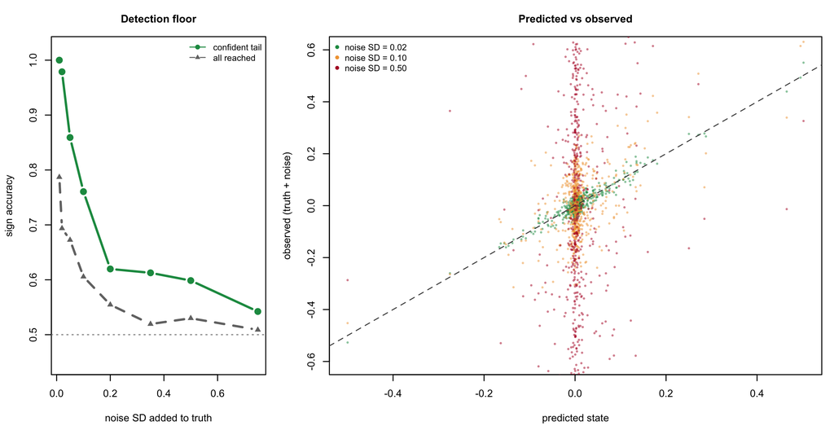

Ground-truth validation (test_propagation.R).

[output not shown]

# 3. Is the seeding assumption even true?

The seeds assume promoter hypermethylation silences a gene. That is the canonical direction, not a law. It had never been measured in this cohort (a known gap in `CLAUDE.md`), so it was measured three ways.

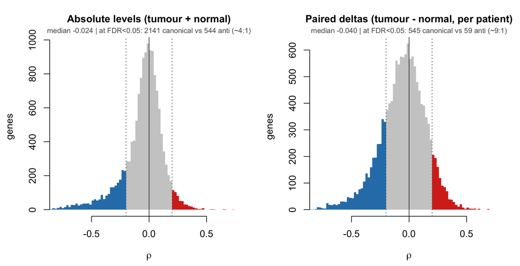

Distribution of per-gene promoter-methylation vs expression correlation. Blue region: canonical silencing. Red: anti-canonical. Both absolute measures are near-symmetric with a modest canonical excess; the paired-delta measure is visibly cleaner, with a 9:1 canonical-to-anti ratio.

The three measures and what they revealed:

Agreement: rho_all vs rho_tumour = 0.971 (near-identical). rho_paired vs rho_all = 0.433 (a genuinely different axis).

| Measure | Median rho | Strong canonical | Canonical : anti |
| --- | --- | --- | --- |
| rho_tumour (within tumours, n=505) | -0.024 | 2058 (14%) | ~4 : 1 |
| rho_all (tumour + normal, n=555) | -0.024 | 2141 (15%) | ~4 : 1 |
| rho_paired (per-patient deltas, n=50) | -0.040 | 545 (4%) | **9 : 1** |

**Only ~14% of genes show canonical promoter silencing.** For the large majority, promoter methylation and expression are effectively uncoupled. This retrospectively explains why an ungated additive prize diluted itself: most prized genes carry no working mechanism.

Pooling normals with tumours changed almost nothing (Spearman **0.971** against tumour-only) because THCA has only 50 normals against 505 tumours. The **paired-delta** measure — per patient, tumour minus normal in *both* modalities — agrees with them at only **0.43**, and is the one that isolates the within-patient mechanism the seeds actually assume.

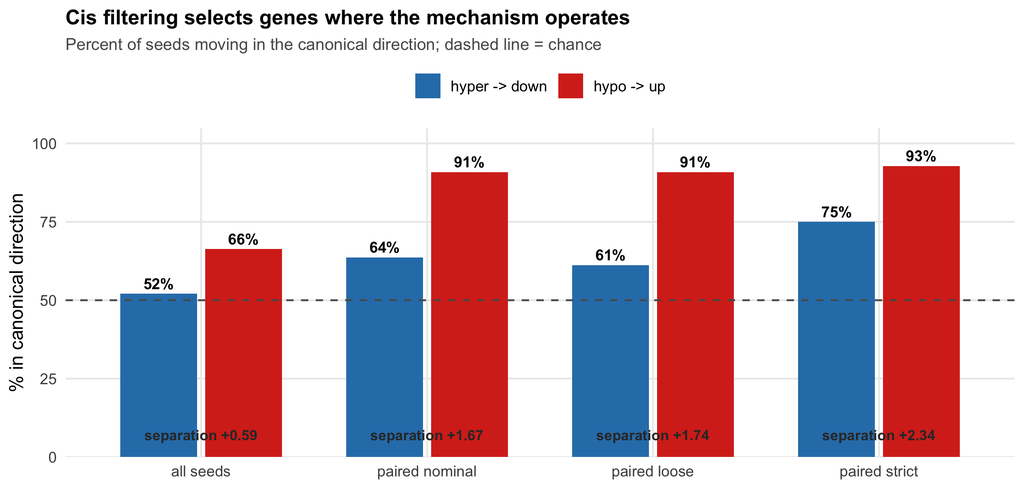

Seed-set quality by cis filter. Dashed line is chance. Tightening the paired filter drives hypermethylated genes toward downregulation and hypomethylated toward upregulation, nearly quadrupling the separation. The filters select genes where the mechanism demonstrably operates.

# 4. Results on real data

## 4.1 The prediction, drawn on the real network

The figure below is the whole idea in one picture: methylation seeds on the left, their predicted downstream consequences propagated through signed OmniPath edges, and the observed expression change drawn beside each prediction.

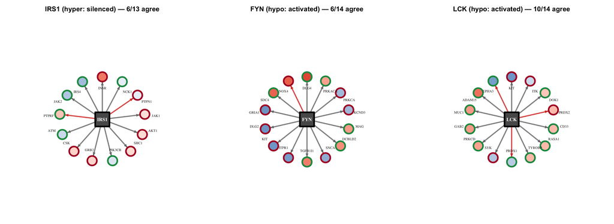

Three methylation seeds and their direct regulatory targets. Centre square is the seed; its methylation state sets the sign. Grey arrows are activation, red blunt connectors inhibition, so the PREDICTED target state is the seed state times the edge sign. Circle fill shows the OBSERVED differential expression (red up, blue down). Green ring = prediction and observation agree, red ring = they disagree. IRS1 is the canonical case: promoter hypermethylation, presumed silenced.

Individual stars show the effect is real but noisy — agreement runs roughly 6/13 to 10/14 across seeds. The quantitative version over every reached gene:

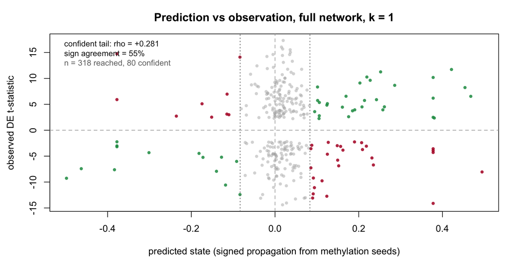

Every significantly-changed gene reached by propagation from paired cis-validated seeds. Coloured points are the confident tail (beyond the dotted thresholds): green where predicted and observed signs agree, red where they do not. Grey points fall below the confidence threshold, where the predicted sign is not meaningful. The positive trend is visible and is the strongest result in the study — and equally visibly, it is a weak trend.

## 4.2 The substrate matters more than the seeds

The headline result, and it was not what was expected:

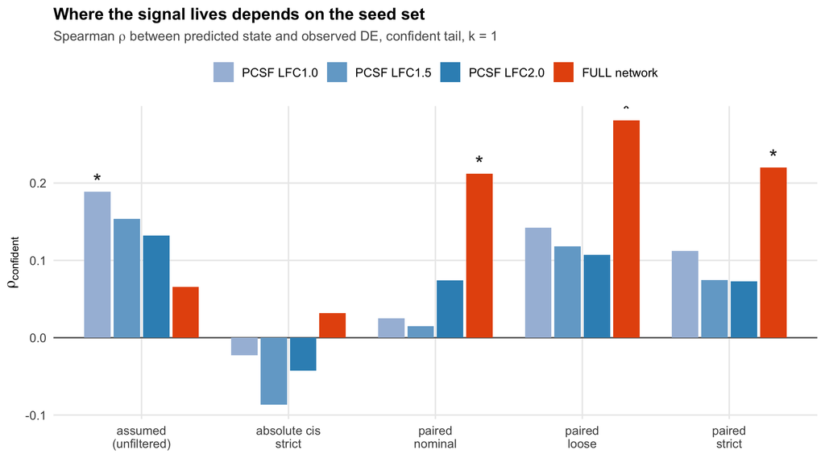

Prediction quality by seed set and evaluation network (k=1). With unfiltered seeds the PCSF subnetworks beat the full network. With cis-validated paired seeds the pattern INVERTS decisively: the full network wins. Stars mark uncorrected p < 0.05; none survive FDR correction.

With **unfiltered** seeds, the PCSF subnetworks beat the full network 3/3 (best $\rho$ = 0.189, sign accuracy 0.606, p = 0.010). With **paired cis-validated** seeds the ordering flips: the full network gives the strongest result in the entire study ($\rho$ = **0.281**, p = **0.0033**) while the subnetworks fall to $\rho \approx 0.14$.

The explanation is structural, and it invalidates the original experiment rather than the idea:

> **PCSF built those subnetworks from expression-driven prizes.** They are organised around differentially expressed genes, not around methylation seeds. The seeds’ real downstream targets largely lie *outside* them, so restricting evaluation to the subnetwork discards precisely the edges the hypothesis needs.

Testing a methylation-seeded hypothesis on an expression-derived subnetwork was the wrong experiment. That is a design error, not a biological finding.

## 4.3 A ceiling: the positive control barely works

The decisive diagnostic. Seed with the strongest DE genes and predict *other* genes’ expression — same assay, same contrast, same samples, no cross-modal gap and no methylation assumption. This is the most favourable test the network can be given.

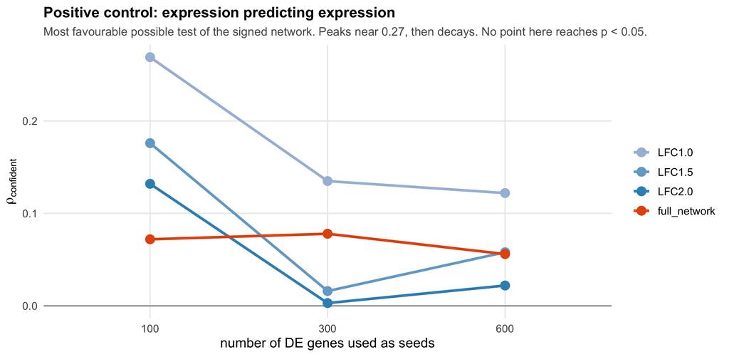

Expression-seeded positive control. Even under ideal conditions the signed propagation model peaks near rho = 0.27 and degrades as seeds are added; almost nothing clears its own degree-matched null. This caps what any amount of seed refinement can achieve.

Best case $\rho$ = 0.269 (sign accuracy 0.633) at 100 seeds, **p = 0.124** — it does not cleanly beat its own null, and it *decays* toward 0.12 as seeds increase. Damped linear propagation over OmniPath simply has limited resolution on this bulk expression field, whatever the seeds are. The modest methylation results are therefore not primarily a seeding failure.

# 5. Statistical honesty

Nothing in this report survives multiple-testing correction.

| Quantity | Value |
| --- | --- |
| Configurations tested (final grid) | 40 |
| Best uncorrected p | 0.0033 |
| Minimum FDR (Benjamini-Hochberg) | 0.132 |
| Results surviving FDR < 0.05 | 0 |

Every effect described here is **suggestive, not established**. Additional caveats worth carrying forward:

- **~26% of subnetwork edges are unsigned** and were dropped from propagation.
- Correlation-based scoring across genes is not independent — network neighbours share regulators, so effective sample size is below the gene count.
- The paired-delta measure rests on **50 patients**; it is specific but underpowered, and its filters are therefore conservative.
- The positive control shares an assay between seeds and targets, so it is a capability check on the network model, **not** independent biological evidence.

# 6. Conclusions

**What was established.**

1. The propagation machinery is **validated** against planted ground truth, with a calibrated null and a known detection floor.
2. The canonical methylation-silencing assumption holds for only about **14%** of genes — measured, not assumed, closing a known gap.
3. The **paired-delta** cis measure is a genuinely different and cleaner axis (9:1 canonical:anti) than absolute-level correlation, and is the correct way to ask this question when paired samples exist.
4. **Two hypotheses were tested and refuted**: that tumour-only correlation was the wrong axis (pooling changed nothing — 0.971 agreement), and that better cis seeds would sharpen the prediction (they did not, on PCSF subnetworks).

**What was not.** No configuration survives multiple-testing correction. The best result — paired seeds on the full network, $\rho$ = 0.281, p = 0.0033 — is promising and unproven.

**The load-bearing conclusion.** Two limits were hit, and they are different in kind. One is a **design error**: scoring a methylation-seeded hypothesis on an expression-derived subnetwork removes the relevant edges, and is fixable. The other is a **capability limit**: the positive control shows damped linear propagation cannot predict this expression field well even under ideal conditions, and no seed curation will fix that.

**Two directions worth more than further seed tuning:**

1. **Match the subnetwork to the hypothesis.** Run PCSF seeded *from the methylation genes toward observed responders*, so the recovered subnetwork and the tested hypothesis concern the same edges.
2. **Replace linear propagation with sign-consistency optimisation.** [CARNIVAL](https://saezlab.github.io/CARNIVAL/) (Saez-Rodriguez lab, same group as OmniPath) solves exactly this problem as an ILP over signed OmniPath, optimising *consistency* rather than diffusing magnitude. The positive control suggests this is the more promising axis of the two.

```
## Generated: 2026-08-16 23:45 | R version 4.6.1 (2026-06-24) | igraph 2.3.3 | Matrix 1.7.6
```